# Alpine Seeds MS

15/6/2020

# 1 Introduction

Alpine environments are those that occur above the maximum elevation at which trees can grow, and are characterized by low temperatures, strong winds, unstable substrates, and short growing seasons (Körner, 2003). The short alpine growing season is a major barrier for plant recruitment, as it constrains the period favorable for seedling establishment (Chambers *et al.*, 1990; Forbis, 2003). Alpine seedlings must survive extreme environmental stresses and yet grow to a critical biomass by the end of the growing season, to withstand the harsh and long-lasting winter (Schütz, 2002). The physiological process of seed germination is the essential, yet most vulnerable, start of seedling establishment (Fenner & Thompson, 2005). Because it is an irreversible process, germination must be timed to occur when the environment is favourable for subsequent seedling survival and growth (Poschlod *et al.*, 2013). Thus, the mechanisms regulating the timing of the seed-to-seedling transition are expected to be under strong selective pressure (Angevine & Chabot, 1979; Willis *et al.*, 2014). Natural selection should favour seed germination requirements that reduce the probability of facing environmental conditions that are not appropriate for seedlings. The main physiological drivers of germination, water availability and temperature (Bewley *et al.*, 2013), are also two main features of climate. In addition, many plant species have developed seed dormancy, by which germination is prevented during periods that are only ephemerally favourable, ensuring germination in the right season (Finch-Savage & Leubner-Metzger, 2006). Different degrees of dormancy also ensure the distribution of offspring emergence across time, as bet-hedging against unpredictable environments (Venable, 2007). Other germination cues allow for a detection of fine-scale germination niches and safe sites (Jumpponen *et al.*, 1999), such as the response to light (Carta *et al.*, 2017) and alternating temperatures (Thompson, 1977). In the alpine environment, the diversity of microhabitats has apparently resulted in variable germination ecologies across species, making it difficult to define a common *alpine germination syndrome* (Körner, 2003; Schwienbacher *et al.*, 2011).

Early studies on the germination ecology of alpine plants demonstrated that freshly collected seeds of most arctic and alpine species required relatively high temperatures for germination (Bliss, 1958; Amen, 1966; Billings & Mooney, 1968). High-temperature germination has been considered to be an adaptation to prevent seed germination at the timing of seed dispersal (autumn), when temperatures are low and there is a high risk of frost (Cavieres & Arroyo, 2000). Indeed, seed germination of alpine species tends to occur after exposure to winter in early summer (Körner, 2003; Mondoni *et al.*, 2015); at this stage the temperature window for germination usually widens towards lower values (Nishitani, 1996). Nevertheless, there is an increasing number of studies highlighting the germination of freshly collected seeds at cool incubation temperatures or even during cold stratification treatments (Schwienbacher *et al.*, 2011; Hoyle *et al.*, 2015; Fernández‐Pascual *et al.*, 2017; Cavieres & Sierra-Almeida, 2018). Low-temperature germination could be an adaptation to germination under snow or at snowmelt, which could presumably allow seedlings to develop a deeper root system before topsoil desiccation in summer (Kammer & Möhl, 2002), as well as to attain an optimal size for overwintering (Billings & Mooney, 1968).

Many alpine species have been described as having deep physiological dormancy (Schwienbacher *et al.*, 2011; Sommerville *et al.*, 2013; Baskin & Baskin, 2014). Dormancy in freshly-dispersed seeds would prevent precocious germination under autumn conditions, when appropriate soil moisture and temperature are not likely to persist for more than a few weeks or days (Meyer & Monsen, 1991). A requirement for cold stratification to break dormancy would allow seeds to sense the snow season, thereby timing germination to a posterior period, more appropriate for seedling survival and growth. Thus, it can be expected that a cold stratification period would be a common requirement for seed germination in alpine plant species. Nonetheless, in an early review, Amen (1966) concluded that cold stratification was not a common requirement for the seed germination of several alpine plant species from different mountains in the USA (see also Sayers and Ward (1966); Marchand and Roach (1980); Kaye (1997)). More recently, Sommerville *et al.* (2013) and Hoyle *et al.* (2015) showed that in 19 and 54 Australian alpine plant species, respectively, a cold stratification period significantly increased seed germination only in half of the species tested. In contrast, Söyrinki (1938, cited in Körner (2003)), experimenting with 91 alpine species from the Alps, found that storage at winter temperatures (i.e. cold stratification) increased seed germination in the great majority of cases. Shimono and Kudo (2005) reported that cold stratification increased seed germination over a range of temperatures in most of the 27 plant species studied in the alpine zone of Japan. Cavieres and Sierra-Almeida (2018) reported that, along an elevational gradient in the central Chilean Andes, cold stratification was an important requirement for seed germination in species from lower elevations, while species from higher sites still did not germinate after cold stratification. Therefore, how important cold stratification is for seed germination in alpine plant species remains unclear and requires a global assessment.

The response of alpine seeds to light and alternating temperatures can provide further information on their capacity to detect fine-scale environmental variation. The preference of some species to germinate in light (Densmore, 1997; Mondoni *et al.*, 2009) could favour the creation of a persistent soil seed bank (Jaganathan *et al.*, 2015), adventageous in temporally and spatially unpredictable alpine environments (Kalin Arroyo *et al.*, 1999; Cavieres & Arroyo, 2001). Some species seem to prefer dark germination (Schwienbacher *et al.*, 2011), a behaviour interpreted by some as detecting safe sites in rock crevices (Arslan *et al.*, 2011). Regarding alternating temperatures, a study of 445 species from the Qinhai-Tibet plateau detected that species from high elevation alpine meadows did not show a significant response to diurnal temperature oscillations (Liu *et al.*, 2013).

# 2 Materials and methods

## 2.2 Description of the dataset

The final dataset contains 9,793 records (germination proportions for a given seed lot of a species, recorded in a set of experimental conditions) contributed by 12 research groups, representing 62 seed plant families and 661 species (291 strict alpine species and 370 generalists). Seed lots had been collected in 8 alpine regions of the world (**Fig. 5.1**), in both hemispheres. The total number of seeds used in the experiments is 365,508. The range of germination temperatures (weighted average of the daily thermoperiod) goes from 0 to 36 ºC, with 7,515 records of constant temperatures and 2,278 of alternating temperatures. Light was used in 8,927 records, darkness in 866. The experiments were performed with unstratified seeds in 7,291 records, and of the rest, the majority (2,436) went through cold stratification. Scarification was applied to 119 records, and GA<sub>3</sub> to 651. Germination incubations had ran for different periods of time, we established a cut-off time of 8 weeks to calculate the final germination percentages, in order to have an homogeneous comparison of germination.

## 2.4 MCMC analysis

Across species, germination and dormancy patterns are affected by a combination of factors such as phylogeny (Nikolaeva, 1977, 1999; Figueroa & Armesto, 2001) and seed traits (Erschbamer & Pfattner, 2002; Bu *et al.*, 2007).

## 2.5 FAMD ordination

# 3 Results

## 3.1 Dormancy classes

Most of the species had some type of seed dormancy (**Fig. 5.2**a), the most common one being physiological (PD). A minority of species were non-dormant (ND), and ND was slightly more frequent in generalist species. The most noticeable difference between generalist and strict species was in the morphological (MD) and morphophysiological (MPD) classes, which were more frequent in the strict alpine species. Physical dormancy (PY) was rare in both strict alpines and generalists.

## 3.2 Seed mass and embryo:endosperm

Both generalist and strict alpine species had a similar range of values for seed mass (**Fig. 5.2**b) and embryo to endosperm ratio (**Fig. 5.2**c). The values of seed mass ranged from 0.02 to 58 mg, with a median of 0.56. Embryo:endosperm encompassed the full range of potential values, from endospermic species with very small embryos (0.001) to non-endospermic seeds (1). The median value was 0.34.

## 3.3 Germination temperature

Temperature had a positive effect on the final germination proportion (**Fig. 5.3**a), indicating a preference for warmer temperatures. Increasing temperatures also decreased germination time (**Fig. 5.3**b) and uncertainty (**Fig. 5.3**c). The effect of warmer temperatures was more intense in strict alpine than in generalist species. Seed mass and embryo:endosperm reduced the response to temperature: heavier and less endospermic seeds increased less their germination proportion and decreased less their germination time in warmer temperatures, although uncertainty did not show an interaction with mass or embryo:endosperm.

## 3.4 Alternating temperatures

Alternating temperatures had a positive effect on the germination proportion (**Fig. 5.3**a), but not in germination time (**Fig. 5.3**b) or uncertainty (**Fig. 5.3**c). The posive effect on the germination proportion was slightly higher in the generalist species. Again, higher seed mass and embryo:endosperm reduced the positive effect of alternating temperatures.

## 3.5 Light

Light enhanced the germination proportion (**Fig. 5.3**a), with no differences between strict alpine and generalist species. It did not affect the germination time (**Fig. 5.3**b), but it did increase the germination uncertainty of generalist species (**Fig. 5.3**c). Heavier and less endospermic seeds responded less to light.

## 3.7 Stratification and GA<sub>3</sub>

# 4 Discussion

The influence of environmental conditions as drivers of these contrasting germination responses to temperature is gaining recognition. For example, alpine species show higher optimal temperatures for germination than either subalpine species (i.e. species that live close to the treeline, Fernández-Pascual *et al.* (2017)) or congeneric counterparts from below the treeline (Walder & Erschbamer, 2015). Differences in germination traits have been attributed also to species successional niche, with pioneer species germinating better at colder temperatures than later successional species (Schwienbacher *et al.*, 2012). Species from calcareous and siliceous alpine grasslands show a slow overwinter germination or high germination under all conditions, respectively (Tudela-Isanta *et al.*, 2018a,b). Other factors related to species germination characteristics include slope (Xu *et al.*, 2017) and biogeographical origin (Giménez-Benavides *et al.*, 2005). Nevertheless, no habitat-related germination strategies were identified when comparing a major divide in alpine microhabitats, as is the one between fellfields and snowbeds (Shimono & Kudo, 2005).

# 5 Figures

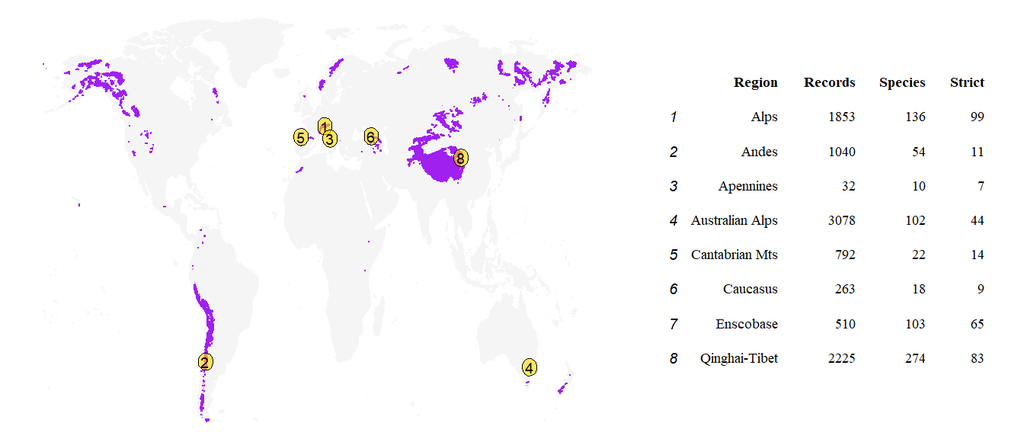

Figure 5.1: Geographical origin of the germination data with the number of records, species and strict alpine species per alpine region. Ensconet is not plotted because its records come from alpine regions throughout Europe. The purple areas correspond to the global extension of alpine environments according to Testolin *et al.* (2020).

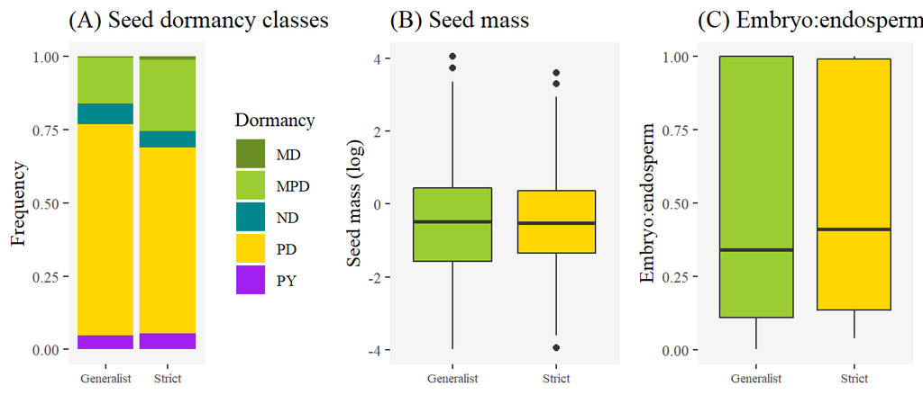

Figure 5.2: Seed dormancy classes, seed mass and embryo to endosperm ratio in generalist and strict alpine species. Seed dormancy classes are abbreviated as follows: MD (morphological), MPD (morphophysiological), ND (non dormant), PD (physiological), PY (physical).

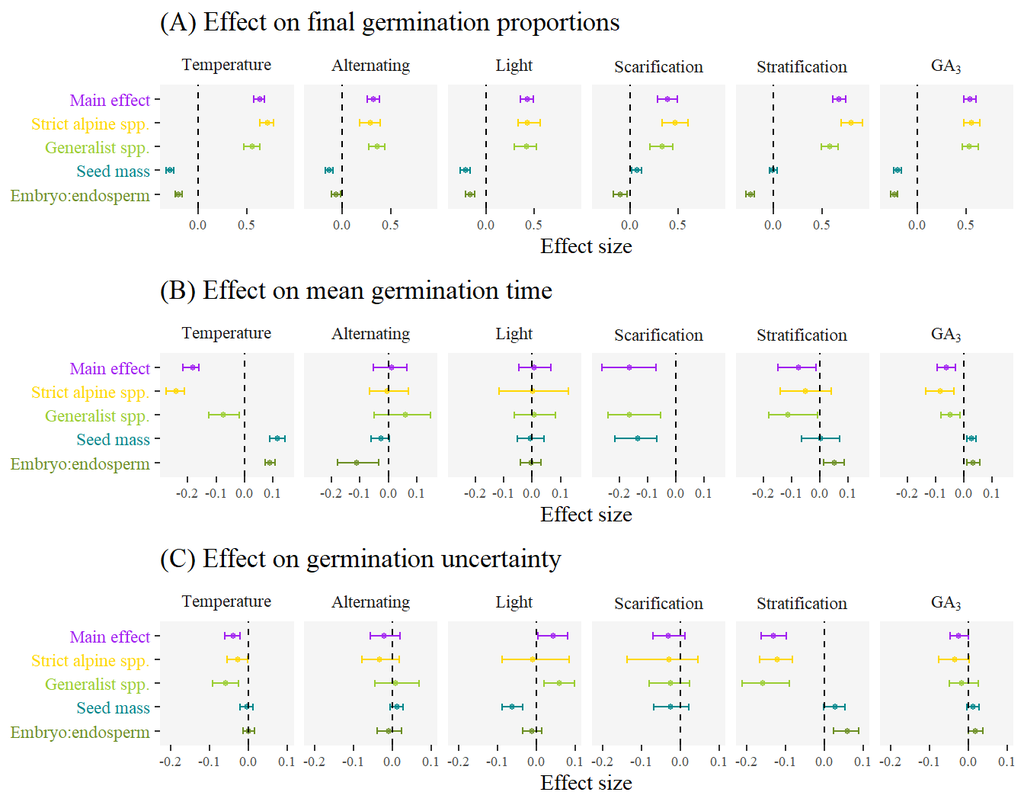

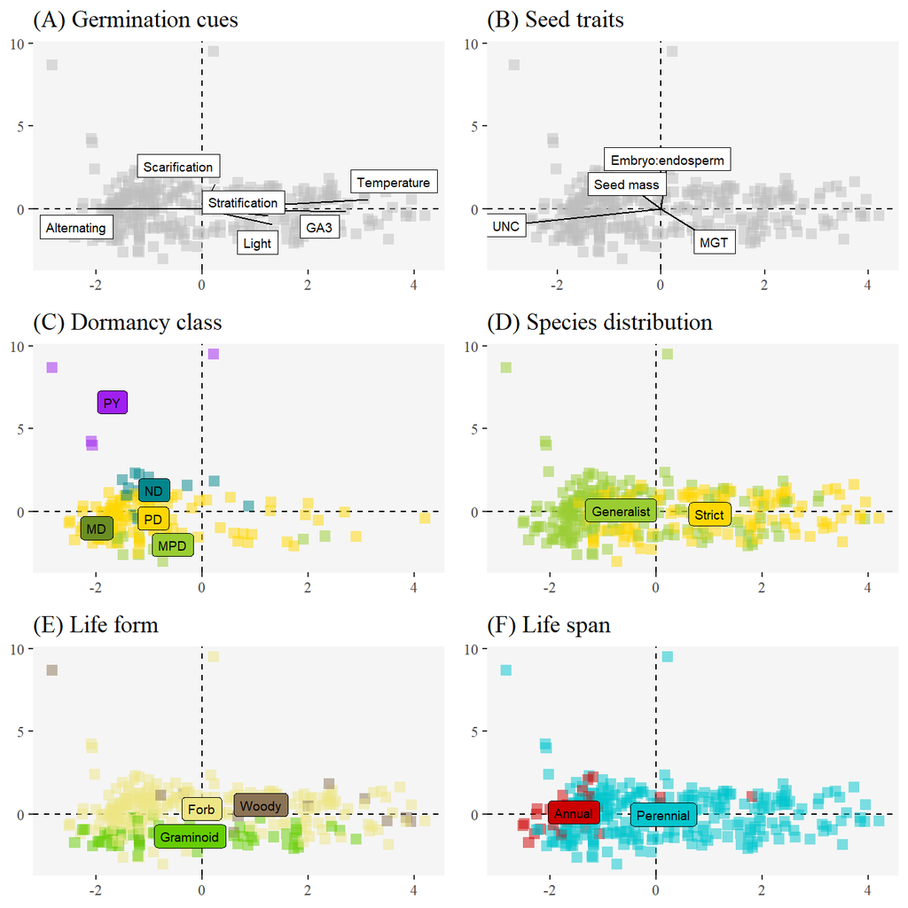

Figure 5.4: FADM ordination of the seed variables and the species distribution, life form and life span.

# References

Al-Shehbaz, I.A. (2018) A monograph of the South American species of Draba (Brassicaceae). *Annals of the Missouri Botanical Garden*, **103**, 463–590.

Amen, R.D. (1966) The extent and role of seed dormancy in alpine plants. *Quarterly Review of Biology*, **41**, 271–281.

Angevine, M.W. & Chabot, B.F. (1979) *Seed germination syndromes in higher plants*. (ed. by O.T. Solbrig), S. Jain), G.B. Johnson), and P.H. Raven), pp. 188–206. Columbia University Press, New York.

Arslan, H., Kirmizi, S., Güleryüz, G. & Sakar, F. (2011) Germination requirements of Androsace villosa L. (Primulaceae). *Acta Biologica Cracoviensia Series Botanica*, **53**, 32–36.

Baskin, C.C. & Baskin, J.M. (2014) *Seeds. Ecology, Biogeography and Evolution of Dormancy and Germination. Second Edition*, Academic Press, San Diego.

Bewley, J.D., Bradford, K., Hilhorst, H. & Nonogaki, H. (2013) *Seeds: Physiology of Development, Germination and Dormancy. 3rd Edition*, Springer, Berlin - Heidelberg - New York.

Billings, W.D. & Mooney, H.A. (1968) The ecology of arctic and alpine plants. *Biological Reviews*, **43**, 481–529.

Bliss, L.C. (1958) Seed germination in arctic and alpine species. *Arctic*, **11**, 180–188.

Brach, A.R. & Song, H. (2006) eFloras: New directions for online floras exemplified by the Flora of China Project. *Taxon*, **55**, 188–192.

Bu, H., Chen, X., Xu, X., Liu, K., Jia, P. & Du, G. (2007) Seed mass and germination in an alpine meadow on the eastern Tsinghai–Tibet plateau. *Plant Ecology*, **191**, 127–149.

Bu, H., Du, G., Chen, X., Xu, X., Liu, K. & Wen, S. (2008) Community-wide germination strategies in an alpine meadow on the eastern Qinghai-Tibet plateau: phylogenetic and life-history correlates. *Plant Ecology*, **195**, 87–98.

Cabrera, Á. l (1982) Revisión del género Nassauvia (Compositae). *Darwiniana*, **24**, 283–379.

Carta, A., Skourti, E., Mattana, E., Vandelook, F. & Thanos, C.A. (2017) Photoinhibition of seed germination: occurrence, ecology and phylogeny. *Seed Science Research*, **27**, 131–153.

Castroviejo, S. (1987) *Flora iberica*, Real Jardín Botánico, CSIC, Madrid.

Cavieres, L.A. & Arroyo, M.T.K. (2001) Persistent soil seed banks in Phacelia secunda (Hydrophyllaceae): experimental detection of variation along an altitudinal gradient in the Andes of central Chile (33 S). *Journal of Ecology*, **89**, 31–39.

Cavieres, L.A. & Arroyo, M.T.K. (2000) Seed germination response to cold stratification period and thermal regime in Phacelia secunda (Hydrophyllaceae). *Plant Ecology*, **149**, 1–8.

Cavieres, L.A. & Sierra-Almeida, A. (2018) Assessing the importance of cold-stratification for seed germination in alpine plant species of the High-Andes of central Chile. *Perspectives in Plant Ecology, Evolution and Systematics*, **30**, 125–131.

Cayuela, L., Stein, A. & Oksanen, J. (2019) Taxonstand: taxonomic standardization of plant species names. R package version 2.2.

Chambers, J.C., MacMahon, J.A. & Brown, R.W. (1990) Alpine seedling establishment: the influence of disturbance type. *Ecology*, **71**, 1323–1341.

Densmore, R. (1997) Effect of day length on germination of seeds collected in Alaska. *Am J Bot*, **84**, 274.

Erschbamer, B. & Pfattner, M. (2002) Das Keimverhalten von alpinen Arten in der Klimakammer und im Gelande. *Berichte des Naturwissenschaftlich-Medizinischen Vereins in Innsbruck*, **89**, 87–98.

Fenner, M. & Thompson, K. (2005) *The Ecology of Seeds*, Cambridge University Press, Cambridge.

Fernández‐Pascual, E., Jiménez‐Alfaro, B., Bueno, Á., Fernández-Pascual, E., Jiménez-Alfaro, B. & Bueno, Á. (2017) Comparative seed germination traits in alpine and subalpine grasslands: higher elevations are associated with warmer germination temperatures. *Plant Biology*, **19**, 32–40.

Figueroa, J.A. & Armesto, J.J. (2001) Community-wide germination strategies in a temperate rainforest of Southern Chile: ecological and evolutionary correlates. *Australian Journal of Botany*, **49**, 411–425.

Finch-Savage, W.E. & Leubner-Metzger, G. (2006) Seed dormancy and the control of germination. *New Phytologist*, **171**, 501–523.

Forbis, T.A. (2003) Seedling demography in an alpine ecosystem. *American Journal of Botany*, **90**, 1197–1206.

Giménez-Benavides, L., Escudero, A. & Pérez-García, F. (2005) Seed germination of high mountain Mediterranean species: altitudinal, interpopulation and interannual variability. *Ecological Research*, **20**, 433–444.

Hegi, G. (1906) *Illustrierte Flora von Mitteleuropa, mit besonderer Berücksichtigung von Deutschland, Österreich und der Schweiz. 1st ed. 1906-1931, 2nd ed. 1936-1979, 3rd ed. 1966-2016.*, Carl Hanser, Paul parey, Weissdorn-Verlag, München, Berlin, Hamburg, Jena.

Hoyle, G.L., Steadman, K.J., Good, R.B., McIntosh, E.J., Galea, L.M.E. & Nicotra, A.B. (2015) Seed germination strategies: an evolutionary trajectory independent of vegetative functional traits. *Frontiers in Plant Science*, **6**, 1–13.

Jaganathan, G.K., Dalrymple, S.E. & Liu, B. (2015) Towards an Understanding of Factors Controlling Seed Bank Composition and Longevity in the Alpine Environment. *The Botanical Review*, **81**, 70–103.

Jumpponen, A., Väre, H., Mattson, K.G., Ohtonen, R. & Trappe, J.M. (1999) Characterization of “safe sites” for pioneers in primary succession on recently deglaciated terrain. *Journal of Ecology*, **87**, 98–105.

Kalin Arroyo, M.T., Cavieres, L.A., Castor, C. & Humaña, A.M. (1999) Persistent soil seed bank and standing vegetation at a high alpine site in the central Chilean Andes. *Oecologia*, **119**, 126–132.

Kammer, P.M. & Möhl, A. (2002) Factors Controlling Species Richness in Alpine Plant Communities: An Assessment of the Importance of Stress and Disturbance. *Arctic, Antarctic, and Alpine Research*, **34**, 398–407.

Kaye, T.N., Liston, A., Love, R., Luoma, D., Meinke, R. & Wilson, M. (1997) Seed dormancy in high elevation plants: implications for ecology and restoration. *Kaye, TN, et al*, 115–120.

Körner, C. (2003) *Alpine Plant Life: Functional Plant Ecology of High Mountain Ecosystems*, 2nd edn. Springer, Berlin - Heidelberg - New York.

Liu, K., Baskin, J.M., Baskin, C.C., Bu, H., Du, G. & Ma, M. (2013) Effect of diurnal fluctuating versus constant temperatures on germination of 445 species from the eastern Tibet Plateau. *PloS one*, **8**, e69364–e69364.

Lozano-Isla, F., Benites-Alfaro, O.E. & Pompelli, M.F. (2019) GerminaR: An R package for germination analysis with the interactive web application “GerminaQuant for R”. *Ecological Research*, **34**, 339–346.

Marchand, P.J. & Roach, D.A. (1980) Reproductive strategies of pioneering alpine species: seed production, dispersal, and germination. *Arctic and Alpine Research*, **12**, 137–146.

Mengersen, K., Gurevitch, J. & Schmid, C.H. (2013) Meta-analysis of primary data. *Handbook of meta-analysis in ecology and evolution*, 300–312.

Meyer, S.E. & Monsen, S.B. (1991) Habitat-correlated variation in mountain big sagebrush (Artemisia tridentata ssp. vaseyana) seed germination patterns. *Ecology*, **72**, 739–742.

Mondoni, A., Daws, M.I., Belotti, J. & Rossi, G. (2009) Germination requirements of the alpine endemic Silene elisabethae Jan: effects of cold stratification, light and GA3. *Seed Science and Technology*, **37**, 79–87.

Mondoni, A., Pedrini, S., Bernareggi, G., Rossi, G., Abeli, T., Probert, R.J., Ghitti, M., Bonomi, C. & Orsenigo, S. (2015) Climate warming could increase recruitment success in glacier foreland plants. *Annals of Botany*, **116**, mcv101–mcv101.

Mondoni, A., Rossi, G., Orsenigo, S. & Probert, R.J. (2012) Climate warming could shift the timing of seed germination in alpine plants. *Annals of Botany*, **110**, 155–164.

Nikolaeva, M.G. (1977) Factors controlling the seed dormancy pattern. *Physiology and Biochemistry of Seed dormancy and Germination*.

Nikolaeva, M.G. (1999) Patterns of seed dormancy and germination as related to plant phylogeny and ecological and geographical conditions of their habitats. *Russian Journal of Plant Physiology*, **46**, 369–373.

Nishitani, T., Satomi; Masuzawa (1996) Germination Characteristics of Two Species of Polygonum in Relation to Their Altitudinal Distribution on Mt. Fuji, Japan. *Arctic and Alpine Research*, **28**, 104–110.

Oberdorfer, E. (2001) *Pflanzensoziologische Exkursionsflora für Deutschland und angrenzende Gebiete. 8th ed.*, Ulmer, Stuttgart.

Parolly, G. & Rohwer, J.G. (2019) *Schmeil-Fischen. Die Flora Deutschlands und angrenzender Länder. 97th ed.*, Quelle & Meyer, Wiesbaden.

Pignatti, S. (1982) *Flora d’Italia. 3 volumes.*, Edagricole, Bologna.

Poschlod, P., Abedi, M., Bartelheimer, M., Drobnik, J., Rosbakh, S. & Saatkamp, A. (2013) *Seed Ecology and Assembly Rules in Plant Communities*. *Vegetation ecology*, pp. 164–202.

R Core Team (2019) R: A language and environment for statistical computing.

Rodriguez, R., Marticorena, C., Alarcón, D., Baeza, C., Cavieres, L., Finot, V.L., Fuentes, N., Kiessling, A., Mihoc, M. & Pauchard, A. (2018) Catálogo de las plantas vasculares de Chile. *Gayana. Botánica*, **75**, 1–430.

Rosbakh, S., Baskin, C.C. & Baskin, J.M. (2020) Nikolaeva et al.’s reference book on seed dormancy and germination. *Ecology*, e03049.

Sayers, R.T., Richard L.; Ward (1966) Germination Responses in Alpine Species. *Botanical Gazette*, **127**, 11–16.

Schütz, W. (2002) Dormancy characteristics and germination timing in two alpine Carex species. *Basic and Applied Ecology*, **3**, 125–134.

Schwienbacher, E., Navarro-Cano, J.A., Neuner, G. & Erschbamer, B. (2012) Correspondence of seed traits with niche position in glacier foreland succession. *Plant Ecology*, **213**, 371–382.

Schwienbacher, E., Navarro-Cano, J.A., Neuner, G. & Erschbamer, B. (2011) Seed dormancy in alpine species. *Flora-Morphology, Distribution, Functional Ecology of Plants*, **206**, 845–856.

Shetekauri, S. & Jacoby, M. (2009) *Gebrigsflora & Bäume des Kaukasus*, Natural History Book Service, Devon.

Shimono, Y. & Kudo, G. (2005) Comparisons of germination traits of alpine plants between fellfield and snowbed habitats. *Ecological Research*, **20**, 189–197.

Sommerville, K.D., Martyn, A.J. & Offord, C.A. (2013) Can seed characteristics or species distribution be used to predict the stratification requirements of herbs in the Australian Alps? *Botanical Journal of the Linnean Society*, **172**, 187–204.

Testolin, R., Attorre, F. & Jiménez-Alfaro, B. (2020) Global distribution and bioclimatic characterization of alpine biomes. *Ecography*, **43**, 779–788.

The Plant List (2013) Version 1.1.

Thompson, J.P.M., K.; Grime (1977) Seed germination in response to diurnal fluctuations of temperature. *Nature*, **267**, 147–9.

Tudela-Isanta, M., Fernández-Pascual, E., Wijayasinghe, M., Orsenigo, S., Rossi, G., Pritchard, H.W. & Mondoni, A. (2018a) Habitat-related seed germination traits in alpine habitats. *Ecology and Evolution*, **8**, 150–161.

Tudela-Isanta, M., Ladouceur, E., Wijayasinghe, M., Pritchard, H.W. & Mondoni, A. (2018b) The seed germination niche limits the distribution of some plant species in calcareous or siliceous alpine bedrocks. *Alpine Botany*, **128**, 83–95.

Venable, D.L. (2007) Bet hedging in a guild of desert annuals. *Ecology*, **88**, 1086–1090.

Venn, S.E. (2007) Plant recruitment across alpine summits in south-eastern Australia.

Venn, S.E. & Morgan, J.W. (2009) Germination Characteristics of Mountain Celery’Aciphylla Glacialis’(F. Muell.) Benth.(Apiaceae). *Victorian Naturalist, The*, **126**, 4.

Walder, T. & Erschbamer, B. (2015) Temperature and drought drive differences in germination responses between congeneric species along altitudinal gradients. *Plant Ecology*, **216**, 1297–1309.

Willis, C.G., Baskin, C.C., Baskin, J.M., Auld, J.R., Venable, D.L., Cavender‐Bares, J., Donohue, K. & Rubio de Casas, R. (2014) The evolution of seed dormancy: environmental cues, evolutionary hubs, and diversification of the seed plants. *New Phytologist*, **203**, 300–309.

Xu, J., Li, W., Zhang, C., Liu, W. & Du, G. (2017) The determinants of seed germination in an alpine/subalpine community on the Eastern Qinghai-Tibetan Plateau. *Ecological Engineering*, **98**, 114–122.

Zavala-Gallo, L., Denham, S. & Pozner, R. (2010) Revisión del género Nastanthus (Calyceraceae). *Gayana. Botánica*, **67**, 158–175.